# Exploration of the abundances

```r
library("tidyverse")
```

[output not shown]

```r
library("here")
```

```
here() starts at /net/pupil1/home/people/s233426/22160/r_for_bio_data_science/projects/group_09_project
```

```
here() starts at /home/marco/group_09_project
```

```r
library("ggridges")
library("patchwork")
source("99_proj_func.R")
```

```r
data_path <- here("data/06_dat_augmented.RData")
load(data_path)
```

### Abundances visualization

```r
abundance <- dataset |>
  select(starts_with("s_"))

mean_species_abundances <- dataset |>
  select(glucose_tolerance) |>
  bind_cols(abundance) |>
  group_by(glucose_tolerance) |>
  summarise(across(everything(),
                   \(x) mean(x,
                             na.rm = TRUE))) |>
  pivot_longer(
    cols = -glucose_tolerance,
    names_to = "species",
    values_to = "mean_abundance"
  ) |>
  pivot_wider(
    names_from = glucose_tolerance,
    values_from = mean_abundance
  ) |>
  arrange(desc(normal))
```

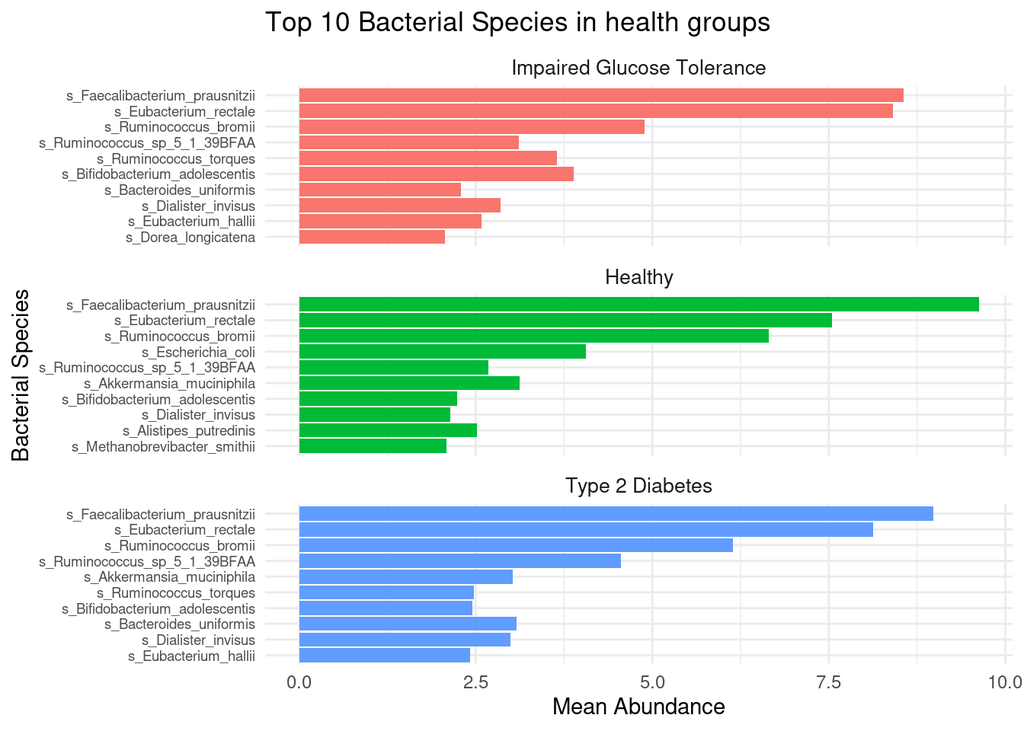

[figure not shown]

```r
# reshape to work on species
result_long <- mean_species_abundances |>
  pivot_longer(cols = -species, names_to = "glucose_tolerance",
               values_to = "mean_abundance")

# get the top 10 abundant species for each glucose_tolerance class
top_species_per_glucose_tolerance <- result_long |>
  group_by(glucose_tolerance) |>
  slice_max(mean_abundance,
            n = 10) |>
  ungroup()

# Create custom labels for the plot
custom_labels <- c(
  "normal" = "Healthy",
  "impaired" = "Impaired Glucose Tolerance",
  "t2d" = "Type 2 Diabetes"
)

# Show the top 10s
top10_species_vs_glucose_tolerance <- top_species_per_glucose_tolerance |>
ggplot(aes(x = reorder(species, mean_abundance),
           y = mean_abundance,
           fill = glucose_tolerance)) +
  geom_bar(stat = "identity") +
  coord_flip() +
  facet_wrap(~ glucose_tolerance, scales = "free_y",
             ncol = 1,
             labeller = labeller(glucose_tolerance = custom_labels)) +
  labs(
    title = "Top 10 Bacterial Species in health groups",
    x = "Bacterial Species",
    y = "Mean Abundance",
    fill = "glucose_tolerance"
  ) +
  theme_minimal() +
  theme(
    legend.position = "none",
    axis.text.y = element_text(size = 7),
    strip.text = element_text(size = 10),
    axis.text.x = element_text(size = 9, angle = 0, hjust = 0.5)
  )

save_plot_custom(
  plot = top10_species_vs_glucose_tolerance,
  filename = "08_top10_species_vs_glucose_tolerance.jpg"
)
top10_species_vs_glucose_tolerance
```

Here we see that the top present species are the same, but this could simply be because they are common gut species.

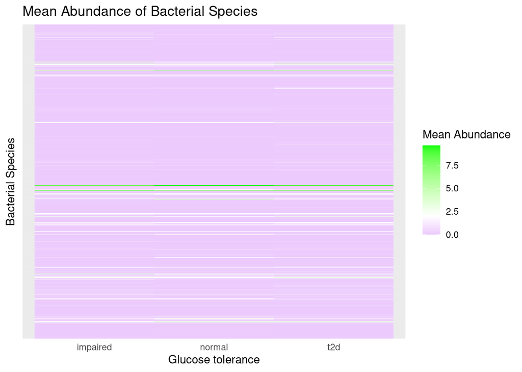

[figure not shown]

```r
species_heatmap <- mean_species_abundances |>
  arrange(desc(t2d)) |>
  #head(100) |>
  pivot_longer(cols = -species,
               names_to = "glucose_tolerance",
               values_to = "mean_abundance") |>
    ggplot(aes(x = glucose_tolerance,
               y = species,
               fill = mean_abundance)) +
      geom_tile() +
      scale_fill_gradient2(low = "purple",
                           mid = "white",
                           high = "green",
                           midpoint = 2) +
      labs(
        title = "Mean Abundance of Bacterial Species",
        x = "Glucose tolerance",
        y = "Bacterial Species",
        fill = "Mean Abundance"
      ) +
      theme_minimal() +
  theme(axis.text.y = element_blank())

save_plot_custom(
  plot = species_heatmap,
  filename = "08_species_heatmap.jpg"
)
species_heatmap
```

Even by looking at the whole microbiota there does not seem to be too much difference between this groups.

```r
species_difference <- mean_species_abundances |>
  mutate(difference = normal-t2d) |>
  select(species, difference) |>
  mutate(comparison = ifelse(difference > 0,
                             "normal>t2d", "t2d>normal")) |>
  mutate(difference = abs(difference)) |>
  arrange(desc(difference))
```

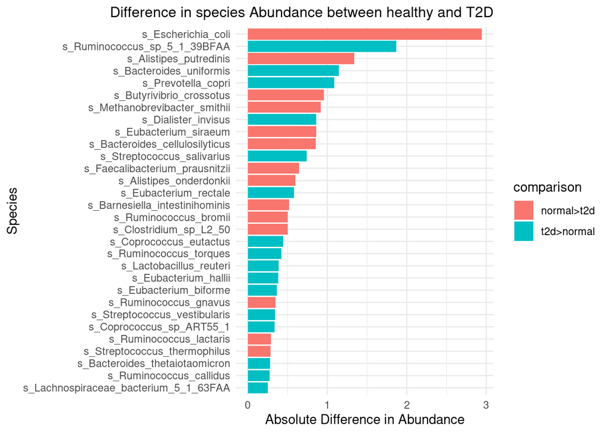

[figure not shown]

```r
most_different_species <- species_difference |>
  head(30) |>
  ggplot(aes(x = difference,
             y = reorder(species, difference),
             fill = comparison)) +
  geom_bar(stat = "identity") +
  labs(
    x = "Absolute Difference in Abundance",
    y = "Species",
    title = "Difference in species Abundance between healthy and T2D"
  ) +
  theme_minimal() +
  theme(
    plot.title = element_text(size = 12, hjust = 1)
  )

save_plot_custom(
  plot = most_different_species,
  filename = "08_most_different_species.jpg"
)
most_different_species
```

Here we can see which are the 30 species that differ the most between healthy and diabetic patients. These can be useful for future analysis or by looking at the literature.

We see that for most of the groups, the value of *s_Escherichia_coli* is almost the same, but we observe a few healthy samples with higher levels.

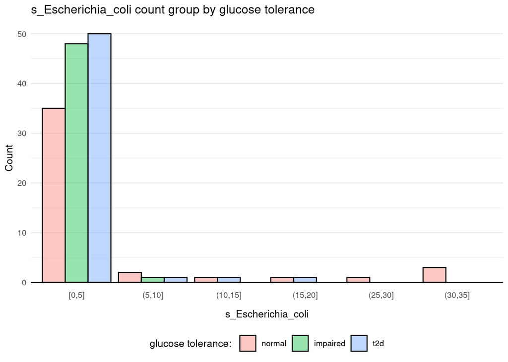

[figure not shown]

```r
ecoli_vs_glucose_tolerance <- dataset |>
  mutate(s_Escherichia_coli_group = cut(
    x = s_Escherichia_coli,
    breaks = seq(from = 0.000,
                 to = 40,
                 by = 5),
    include.lowest = TRUE)) |>
  count(glucose_tolerance,s_Escherichia_coli_group) |>
  ggplot(aes(x = s_Escherichia_coli_group,
             y = n,
             fill = glucose_tolerance)) +
  geom_col(position = position_dodge(
    preserve = "single"),
    colour = "black",
    alpha = 0.4) +
  geom_hline(yintercept = 0) +
  theme_minimal(base_size = 10) +
  labs(x = "s_Escherichia_coli",
       y = "Count",
       title = "s_Escherichia_coli count group by glucose tolerance",
       fill = "glucose tolerance: ")+
  theme(legend.position = "bottom",
        panel.grid.major.x = element_blank(),
        axis.text.x = element_text(vjust = 5))

save_plot_custom(
  plot = ecoli_vs_glucose_tolerance,
  filename = "08_ecoli_vs_glucose_tolerance.jpg"
)

ecoli_vs_glucose_tolerance
```

Then we also want to investigate where the combination of the two most different bacteria would provide more insight, but as we see below, we cannot find a meaningful relationship.

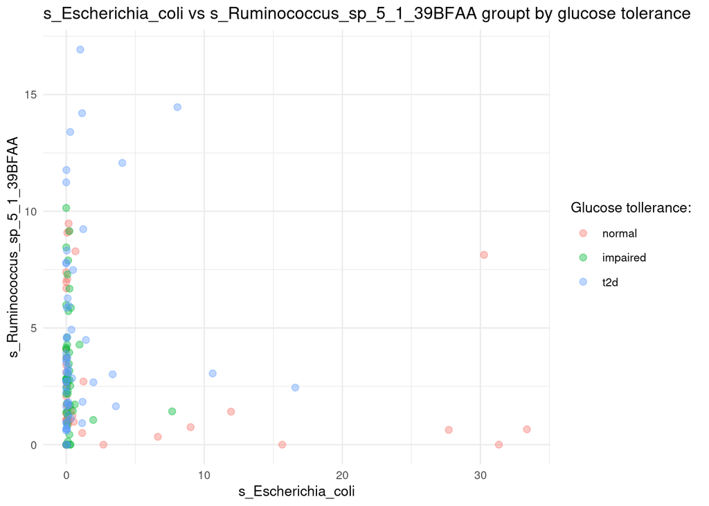

[figure not shown]

```r
ecoli_vs_raminococcus_glucose_tolerance <- dataset |>
  ggplot(aes(x = s_Escherichia_coli,
             y = s_Ruminococcus_sp_5_1_39BFAA,
             colour = glucose_tolerance)) +
  geom_point(size = 2,
             alpha = 0.4) +
  labs(x = "s_Escherichia_coli",
       y = "s_Ruminococcus_sp_5_1_39BFAA",
       title = "s_Escherichia_coli vs s_Ruminococcus_sp_5_1_39BFAA groupt by glucose tolerance",
       colour = "Glucose tollerance: ")+
  theme_minimal(base_size = 10)

save_plot_custom(
  plot = ecoli_vs_raminococcus_glucose_tolerance,
  filename = "08_ecoli_vs_raminococcus_glucose_tolerance.jpg"
)
ecoli_vs_raminococcus_glucose_tolerance
```